# Predicting Human Behavior

Chris Knutson

April 9, 2016

## Predicting Human Activity

#### Predicting the method of activity using ‘Quantified Self’ data

### Exploring the Data

The training data contains data collected from sensors that track human activity. Each data element includes timestamp data, but a brief exploration of the data doesn’t appear to correlate outcomes to the timestamps, so we will not treat this as time series data.

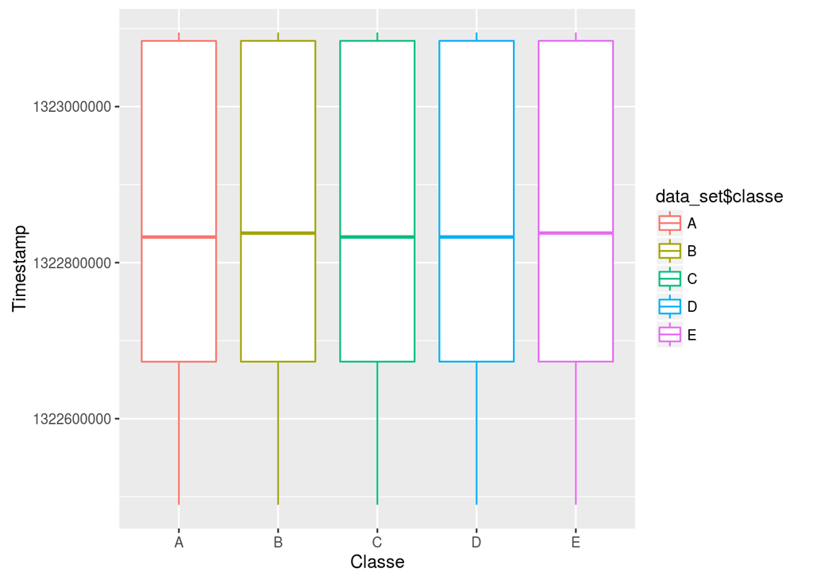

```r
library(knitr)
opts_chunk$set(message = F, error = F, warning = F, comment = NA, fig.align = 'center', dpi = 100, tidy = F, cache.path = '.cache/', fig.path = 'images/')
library(caret)
library(ggplot2)

data_set <- read.csv('hardata/pml-training.csv')
data_set$fulltimestamp <- as.numeric(
    data_set$raw_timestamp_part_1) + as.numeric(data_set$raw_timestamp_part_2 * 0.000001)
qplot(data_set$classe, data_set$fulltimestamp, color=data_set$classe,
      xlab="Classe", ylab="Timestamp", geom="boxplot")
```

### Cleaning the data

The data set contains a large amount of data that is stimply statistics calculated on the observed data. We’ll remove the statistical data as well as the time series data, so they do not bias our results.

```r
get_columns <- function(data){
    # filter out statistical data columns
    column_names <- names(data)
    filter_columns <- c()
    cleaned_data <- data$classe
    stat_prefixes <- c('total', 'kurtosis', 'skewness', 'max', 'min', 'amplitude', 'var', 'stddev', 'avg')
    for(prefix in stat_prefixes){
        stat_columns <- grep(prefix, column_names)
        filter_columns <- c(filter_columns, stat_columns)
    }

    filtered_columns <- column_names[-filter_columns]

    # Grab only sensor related columns
    required_columns <- 'classe'
    sensors <- c('dumbbell', 'arm', 'belt')
    for(sensor in sensors){
        sensor_columns <- grep(sensor, filtered_columns)
        sensor_colnames <- filtered_columns[sensor_columns]
        required_columns <- c(required_columns, sensor_colnames)
    }
    return(required_columns)
}

desired_columns <- get_columns(data_set)
data_set <- data_set[,desired_columns]
```

For a quick was to possibly eliminate weak predictors, we performed a near zero variance check and found no predictors to be near zero variance.

```r
inTrain <- createDataPartition(y=data_set$classe, p=0.8, list=FALSE)
training_set <- data_set[inTrain,]
testing_set <- data_set[-inTrain,]

nearZeroVar(data_set, saveMetrics=TRUE)
```

```
                  freqRatio percentUnique zeroVar   nzv
classe             1.469581     0.0254816   FALSE FALSE
roll_dumbbell      1.022388    84.2065029   FALSE FALSE
pitch_dumbbell     2.277372    81.7449801   FALSE FALSE
yaw_dumbbell       1.132231    83.4828254   FALSE FALSE
gyros_dumbbell_x   1.003268     1.2282132   FALSE FALSE
gyros_dumbbell_y   1.264957     1.4167771   FALSE FALSE
gyros_dumbbell_z   1.060100     1.0498420   FALSE FALSE
accel_dumbbell_x   1.018018     2.1659362   FALSE FALSE
accel_dumbbell_y   1.053061     2.3748853   FALSE FALSE
accel_dumbbell_z   1.133333     2.0894914   FALSE FALSE
magnet_dumbbell_x  1.098266     5.7486495   FALSE FALSE
magnet_dumbbell_y  1.197740     4.3012945   FALSE FALSE
magnet_dumbbell_z  1.020833     3.4451126   FALSE FALSE
roll_arm          52.338462    13.5256345   FALSE FALSE
pitch_arm         87.256410    15.7323412   FALSE FALSE
yaw_arm           33.029126    14.6570176   FALSE FALSE
gyros_arm_x        1.015504     3.2769341   FALSE FALSE
gyros_arm_y        1.454369     1.9162165   FALSE FALSE
gyros_arm_z        1.110687     1.2638875   FALSE FALSE
accel_arm_x        1.017341     3.9598410   FALSE FALSE
accel_arm_y        1.140187     2.7367241   FALSE FALSE
accel_arm_z        1.128000     4.0362858   FALSE FALSE
magnet_arm_x       1.000000     6.8239731   FALSE FALSE
magnet_arm_y       1.056818     4.4439914   FALSE FALSE
magnet_arm_z       1.036364     6.4468454   FALSE FALSE
roll_forearm      11.589286    11.0895933   FALSE FALSE
pitch_forearm     65.983051    14.8557741   FALSE FALSE
yaw_forearm       15.322835    10.1467740   FALSE FALSE
gyros_forearm_x    1.059273     1.5187035   FALSE FALSE
gyros_forearm_y    1.036554     3.7763735   FALSE FALSE
gyros_forearm_z    1.122917     1.5645704   FALSE FALSE
accel_forearm_x    1.126437     4.0464784   FALSE FALSE
accel_forearm_y    1.059406     5.1116094   FALSE FALSE
accel_forearm_z    1.006250     2.9558659   FALSE FALSE
magnet_forearm_x   1.012346     7.7667924   FALSE FALSE
magnet_forearm_y   1.246914     9.5403119   FALSE FALSE
magnet_forearm_z   1.000000     8.5771073   FALSE FALSE
roll_belt          1.101904     6.7781062   FALSE FALSE
pitch_belt         1.036082     9.3772296   FALSE FALSE
yaw_belt           1.058480     9.9734991   FALSE FALSE
gyros_belt_x       1.058651     0.7134849   FALSE FALSE
gyros_belt_y       1.144000     0.3516461   FALSE FALSE
gyros_belt_z       1.066214     0.8612782   FALSE FALSE
accel_belt_x       1.055412     0.8357966   FALSE FALSE
accel_belt_y       1.113725     0.7287738   FALSE FALSE
accel_belt_z       1.078767     1.5237998   FALSE FALSE
magnet_belt_x      1.090141     1.6664968   FALSE FALSE
magnet_belt_y      1.099688     1.5187035   FALSE FALSE
magnet_belt_z      1.006369     2.3290184   FALSE FALSE
```

### Cross-validation

For the rest of feature selection, we’ll let Caret’s train function choose our predictors, but we analyze our best model using cross-validation.

To find the best classification or regression model, we’ll perform cross-validation with k-fold cross-validation, splitting the training data into 5 folds. This will validate a model fit of 80% of the training data against 20% validation partition

```r
library(parallel)
library(doParallel)
set.seed(172)

folds = createFolds(training_set$classe, k=5)
model_methods <- c('lda', 'rpart', 'treebag')

cluster <- makeCluster(detectCores() - 1)
registerDoParallel(cluster)
tc <- trainControl(allowParallel = TRUE)
for(method in model_methods){
    results <- sapply(folds, function(fold) {
        training_fold <- training_set[-fold,]
        validation_fold <- training_set[fold,]
        print(sprintf('fitting new %s model', method))
        if(method=='treebag'){
            fit <- train(classe ~ ., method=method, trainControl=tc, data=training_fold)
        } else {
            fit <- train(classe ~ ., method=method, data=training_fold)
        }
        pred <- predict(fit, validation_fold)
        result <- confusionMatrix(pred, validation_fold$classe)$overall['Accuracy']
    })
    print(sprintf('%s results: ', method))
    print(results)
}
```

```
[1] "fitting new lda model"
[1] "fitting new lda model"
[1] "fitting new lda model"
[1] "fitting new lda model"
[1] "fitting new lda model"
[1] "lda results: "
Fold1.Accuracy Fold2.Accuracy Fold3.Accuracy Fold4.Accuracy Fold5.Accuracy
     0.6942675      0.7029608      0.6891720      0.7033142      0.6812102
[1] "fitting new rpart model"
[1] "fitting new rpart model"
[1] "fitting new rpart model"
[1] "fitting new rpart model"
[1] "fitting new rpart model"
[1] "rpart results: "
Fold1.Accuracy Fold2.Accuracy Fold3.Accuracy Fold4.Accuracy Fold5.Accuracy
     0.5512739      0.5125756      0.4894904      0.5219885      0.4856688
[1] "fitting new treebag model"
[1] "fitting new treebag model"
[1] "fitting new treebag model"
[1] "fitting new treebag model"
[1] "fitting new treebag model"
[1] "treebag results: "
Fold1.Accuracy Fold2.Accuracy Fold3.Accuracy Fold4.Accuracy Fold5.Accuracy
     0.9853503      0.9875836      0.9856688      0.9850223      0.9773885
```

```r
stopCluster(cluster)
```

### Final Model

```r
cluster <- makeCluster(detectCores() - 1)
registerDoParallel(cluster)
tc <- trainControl(allowParallel = TRUE)
finalModelFit <- train(classe ~ ., method='treebag', trainControl=tc, data=training_set)
stopCluster(cluster)
```

### Results

The accuracy of the model was tested against the 20% partition of the training data that was reserved for the tesing set.

```r
predictions <- predict(finalModelFit, testing_set)
accuracy <- sum(predictions == testing_set$classe)/length(predictions)
print(accuracy)
```

```
[1] 0.9900586
```

```r
print(confusionMatrix(predictions, testing_set$classe)$overall['Accuracy'])
```

```
 Accuracy
0.9900586
```

Based on evaluation against the reserved testing set, I believe afinal estimated Out of Sample prediction accuracy of 99.01%.